# Analiza wydatku energetycznego i stylu życia - projekt zespołowy

Maja Kowalska, Ewa Zacharewicz, Kinga Posłuszny

2026-01-31

# 1. Wstęp

### Kontekst i cel opracowania

W dobie rosnącej świadomości prozdrowotnej oraz postępującej personalizacji programów fitness, zrozumienie korelacji między stylem życia a fizjologiczną odpowiedzią organizmu staje się kluczowe dla optymalizacji wyników sportowych. Niniejszy raport stanowi kompleksowe opracowanie analityczne oparte na obszernym zbiorze danych obejmującym **19 996 rekordów**. Głównym celem badania jest identyfikacja kluczowych determinantów wydatku energetycznego oraz analiza wpływu demografii, nawyków żywieniowych i stażu treningowego na profil biometryczny uczestników.

### Metodologia badawcza

Aby zapewnić najwyższą rzetelność wnioskowania, w raporcie wykorzystano zaawansowane narzędzia statystyczne. Integralność danych została potwierdzona rygorystyczną walidacją logiczną, która wykazała **100-procentową kompletność zbioru**. W procesie analitycznym posłużono się:

- **Statystyką opisową** do wyznaczenia trendów centralnych i rozkładów zmiennych.
- **Modelami regresji liniowej** w celu określenia predyktorów spalania kalorii.
- **Analizą wariancji (ANOVA)** oraz testami **Chi-kwadrat** dla weryfikacji istotności różnic międzygrupowych.

## Pytania badawcze

**Efektywność treningowa i wydatkowanie energii**

1. Jak typ treningu i Czas trwania sesji wpływają łącznie na liczbę spalonych kalorii?
2. Jaka jest zależność między Częstotliwością treningów a Spalonymi kaloriami, kontrolując zmienne demograficzne, takie jak Wiek i Płeć?
3. Jak docelowa grupa mięśniowa i Poziom trudności ćwiczenia wpływają na szacunkową liczbę spalonych kalorii na 30 min?

**Fizjologia i profil biometryczny**

4. W jakim stopniu Poziom doświadczenia uczestnika koreluje z jego Tętnem spoczynkowym oraz Średnim tętnem podczas treningu?
5. Czy istnieje związek między Typem diety a Procentem tkanki tłuszczowej lub BMI uczestników?

**Dieta i nawyki żywieniowe**

6. Czy dzienne spożycie makroskładników (Carbs, Proteins, Fats) różni się znacząco w zależności od Typu treningu najczęściej wybieranego przez uczestnika?
7. Jak zawartość Cukru, Sodu i Cholesterolu w posiłkach różni się między różnymi Typami diet?
8. W jaki sposób Metoda gotowania i Czas przygotowania wpływają na to, czy posiłek jest oznaczony jako Zdrowy?

**Behawiorystyka i demografia**

9. Czy Wiek i Płeć uczestników mają związek z wyborem Typu treningu lub Poziomem trudności ćwiczeń?
10. Czy istnieje korelacja między Spożyciem wody a Czasem trwania sesji lub Częstotliwością treningów?

## Opis danych

Zbiór danych zawiera 20000 obserwacji i 54 zmiennych.

Poniżej znajduje się opis najważniejszych zmiennych:

- `Wiek`: wiek uczestnika w latach.
- `Płeć`: płeć uczestnika (Mężczyzna/Kobieta).
- `BMI`: wskaźnik masy ciała uczestnika.
- `Procent tkanki tłuszczowej`: procentowa zawartość tkanki tłuszczowej w organizmie uczestnika.
- `Typ treningu`: kategoria treningu wykonywanego przez uczestnika (np. siłowy, cardio, mieszany).
- `Czas trwania sesji`: czas trwania jednej sesji treningowej w minutach.
- `Liczba spalonych kalorii`: liczba kalorii spalonych podczas jednej sesji treningowej.
- `Typ diety`: kategoria diety stosowanej przez uczestnika.
- `Poziom doświadczenia`: poziom zaawansowania uczestnika w treningach.
- `Tętno spoczynkowe`: tętno uczestnika w stanie spoczynku.
- `Średnie tętno podczas treningu`: średnie tętno uczestnika podczas sesji treningowej.
- `Częstotliwość treningów`: liczba treningów wykonywanych przez uczestnika w tygodniu.
- `Metoda gotowania`: sposób przygotowania posiłków.
- `Czas przygotowania`: czas potrzebny na przygotowanie posiłku w minutach.
- `Zdrowy posiłek`: wskaźnik, czy posiłek jest uważany za zdrowy (Tak/Nie).
- `Spożycie wody`: ilość wody spożywanej przez uczestnika dziennie w litrach.

# 2. Porządkowanie i czyszczenie danych

### Braki danych

Przeprowadzona analiza integralności zbioru danych wykazała **stuprocentową kompletność rekordów** (brak wartości NA), co jest rzadko spotykanym zjawiskiem w surowych zbiorach danych i świadczy o wysokiej jakości źródła.

Dzięki nienagannej strukturze surowego zbioru danych oraz braku jakichkolwiek braków danych czy błędów logicznych, etap czyszczenia ograniczono wyłącznie do technicznego przygotowania zmiennych, co pozwoliło na zachowanie pełnej liczebności próby i gwarantuje najwyższą wiarygodność wyników statystycznych

W danych znajduje się 100 % kompletnych wartości

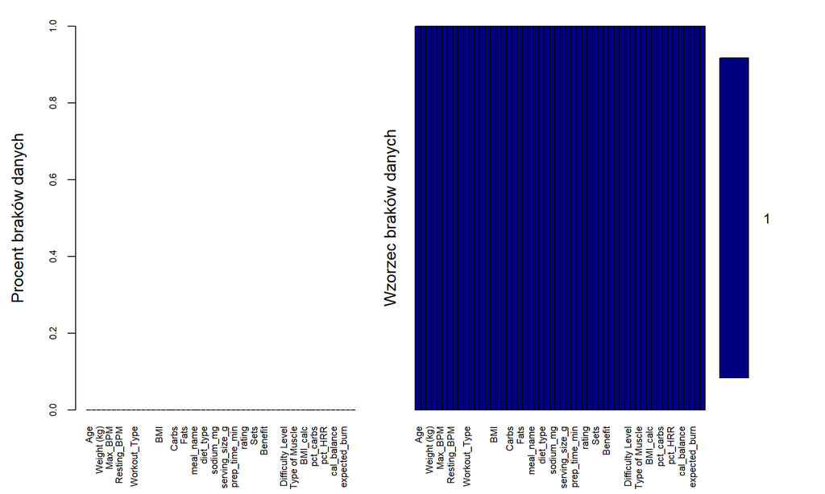

## Walidacja danych

Proces walidacji logicznej (reguły V1-V6) potwierdził, że dane są spójne wewnętrznie:

- Wszyscy respondenci są osobami pełnoletnimi (Age>18).
- Parametry biometryczne, takie jak BMI (zakres 10–50) oraz tętno spoczynkowe, mieszczą się w fizjologicznych granicach normy.
- Zbiór obserwacji przeszedł testy bez ani jednego błędu (fails = 0), co stanowi solidny fundament pod dalsze modelowanie statystyczne bez ryzyka obciążenia wynikającego z błędów grubych.

**Definicja**

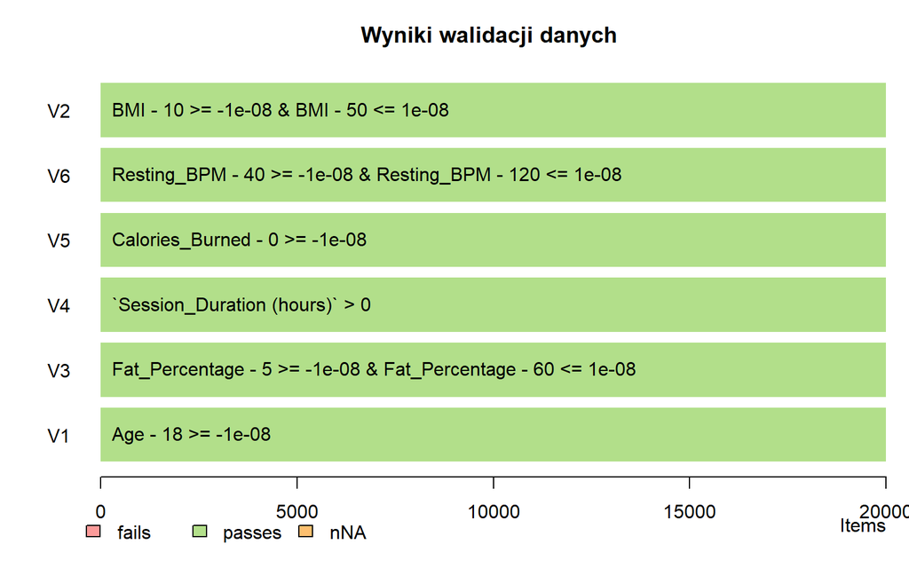

# 3. Wizualizacja danych

## Modelowanie wydatku energetycznego: Wpływ rodzaju i czasu trwania treningu

[interactive chart not shown]

Przeprowadzona analiza regresji potwierdza silną, liniową zależność między czasem trwania sesji a wydatkiem energetycznym we wszystkich grupach badawczych. Odnotowano istotne zróżnicowanie efektywności metabolicznej poszczególnych dyscyplin, z wyraźną dominacją treningu **HIIT**, który generuje blisko dwukrotnie wyższe spalanie w porównaniu do Jogi.

Hierarchia intensywności kształtuje się w sposób następujący: **HIIT > Strength > Cardio > Yoga**. Minimalna dyspersja punktów wokół linii trendu wskazuje na wysoką powtarzalność wyników oraz stabilność parametrów spalania dla każdego z badanych typów wysiłku.

## Wpływ systematyczności treningowej na bilans kaloryczny

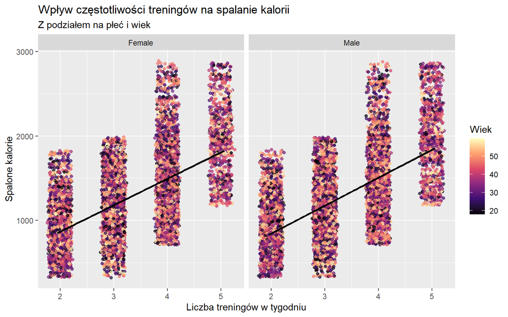

Analiza wykazuje silną, dodatnią korelację liniową między częstotliwością treningów a liczbą spalonych kalorii, niezależną od płci badanych osób. Równomierne rozproszenie punktów wiekowych w całym zbiorze danych potwierdza, że korzyści z regularnej aktywności fizycznej są uniwersalne dla różnych grup wiekowych. Trend wzrostowy pozostaje stabilny dla obu analizowanych grup, choć przy wyższej liczbie sesji treningowych obserwuje się większe zróżnicowanie indywidualnych wyników wydatku energetycznego.

## Analiza intensywności metabolicznej: Cel trneingowy a stopień zaawansowania

[interactive chart not shown]

Najwyższy wydatek energetyczny w badanym okresie 30 minut generuje trening obręczy barkowej na poziomie średniozaawansowanym, osiągając wartość ok. 346 kcal. U osób początkujących największą efektywność pod kątem spalania kalorii wykazują ćwiczenia nóg i pośladków, podczas gdy treningi ogólnorozwojowe oraz mięśni brzucha charakteryzują się wysoką stabilnością wyników niezależnie od stopnia trudności. Całkowite zróżnicowanie efektów mieści się w wąskim przedziale 343–346 kcal, co świadczy o relatywnie wyrównanej intensywności wszystkich analizowanych jednostek treningowych.

## Wpływ modeli żywieniowych na kompozycję ciała i parametry biometryczne

[interactive chart not shown]

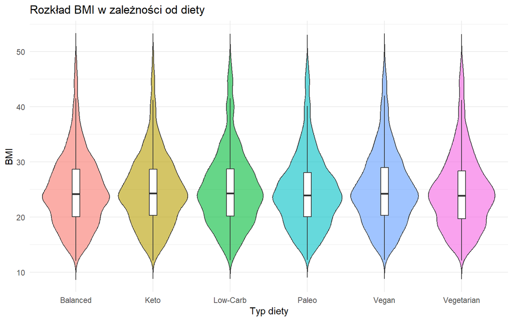

## Charakterystyka kardiologiczna: Adaptacja wysiłkowa vs Poziom doświadczenia

[figure not shown]

Analiza wskazuje na wyraźną separację fizjologiczną między tętnem spoczynkowym a treningowym, niezależnie od stopnia zaawansowania uczestników. Tętno spoczynkowe utrzymuje stabilny poziom w granicach 60–65 BPM, podczas gdy średnie tętno wysiłkowe jest ponad dwukrotnie wyższe, osiągając wartość ok. 145 BPM. Parametry treningowe charakteryzują się znacznie większą zmiennością wyników w porównaniu do stabilnych pomiarów w fazie spoczynku. Dane te potwierdzają prawidłową, typową reakcję układu krążenia na obciążenie fizyczne u wszystkich badanych osób.

## Determinanty czasu przygotowania posiłków w kontekście metod kulinarnych

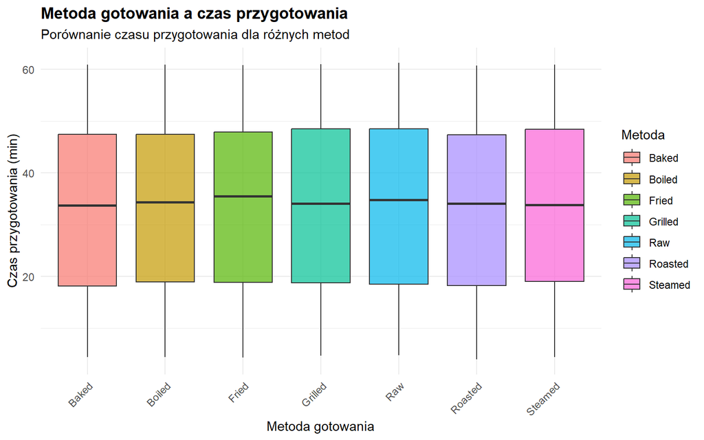

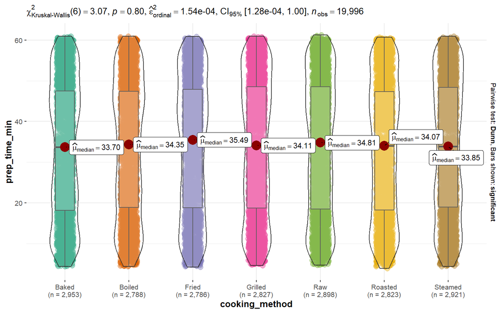

Analiza metod gotowania w odniesieniu do czasu przygotowania posiłków wykazuje wysoką jednorodność danych we wszystkich badanych kategoriach. Mediana czasu przyrządzania potraw oscyluje stabilnie wokół 34–35 minut, niezależnie od tego, czy posiłek jest smażony, gotowany na parze czy spożywany na surowo. Zarówno rozkłady pudełkowe, jak i gęstości (wykresy skrzypcowe) potwierdzają niemal identyczne zakresy zmienności dla każdej z siedmiu analizowanych technik. Statystyczny brak istotnych różnic sugeruje, że wybór konkretnej metody kulinarnej nie determinuje w sposób znaczący czasu poświęcanego na przygotowanie zdrowego posiłku.

## Struktura spożycia makroskładników w relacji do dyscypliny sportowej

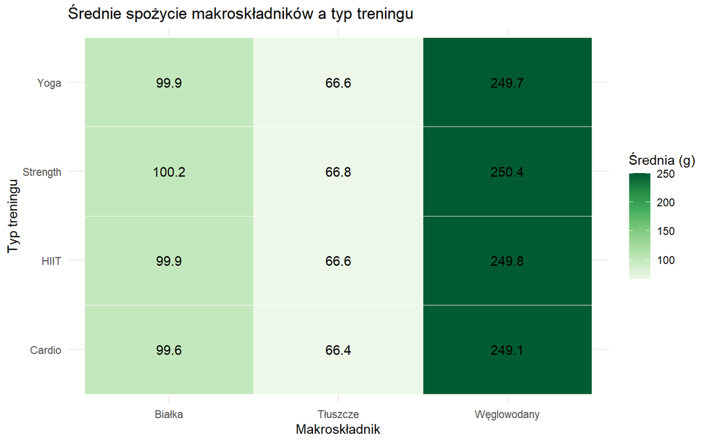

Średnie spożycie makroskładników pozostaje stałe we wszystkich grupach i jest niezależne od rodzaju uprawianego treningu. Wartości białka (100 g), tłuszczów (66 g) oraz węglowodanów (250 g) wykazują minimalną zmienność między osobami trenującymi jogę, HIIT, cardio czy siłowo. Brak korelacji między dyscypliną sportu a strukturą diety sugeruje jednolite nawyki żywieniowe w całej badanej populacji. Oznacza to, że rodzaj aktywności fizycznej nie różnicuje sposobu odżywiania badanych osób.

## Analiza składników krytycznych w ramach różnych modeli dietetycznych

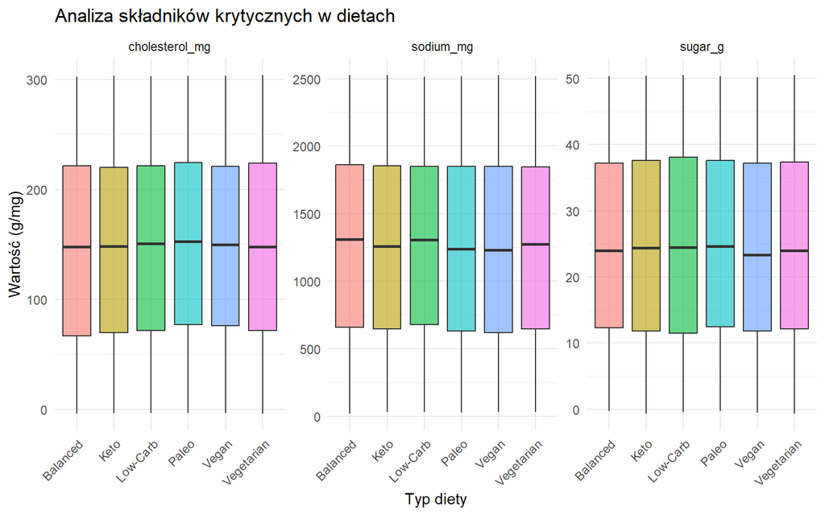

Analiza zawartości cholesterolu, sodu oraz cukru wykazuje niemal identyczne profile odżywcze dla wszystkich sześciu badanych typów diet. Mediany oraz zakresy międzykwartylowe dla poszczególnych składników krytycznych utrzymują się na stałym poziomie, niezależnie od tego, czy badani stosują model Keto, wegański czy zrównoważony. Brak istotnego zróżnicowania sugeruje, że w analizowanej populacji sam wybór etykiety dietetycznej nie gwarantuje niższej podaży tych parametrów metabolicznych. Dane te wskazują na wysoką homogeniczność składu jakościowego posiłków we wszystkich grupach uczestników.

## Neutralność demograficzna w doborze parametrów treningowych

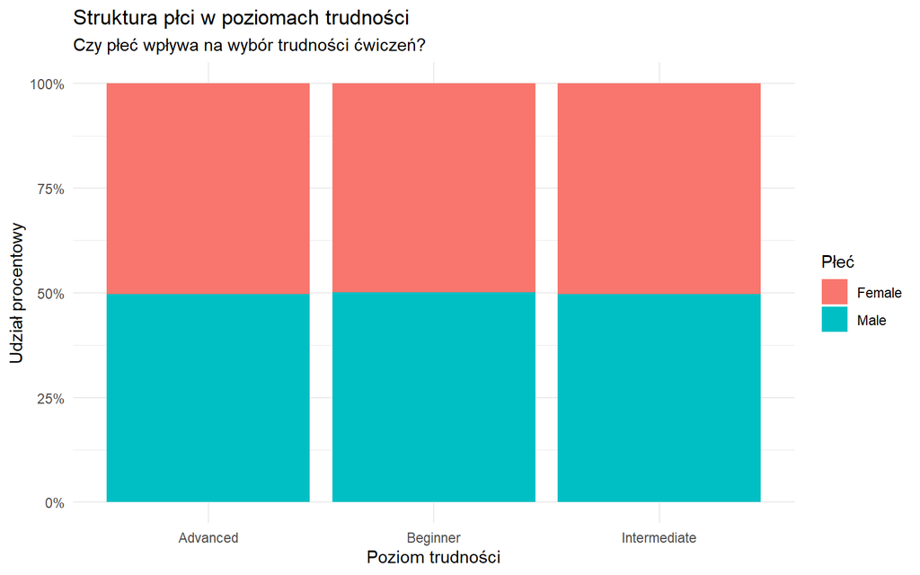

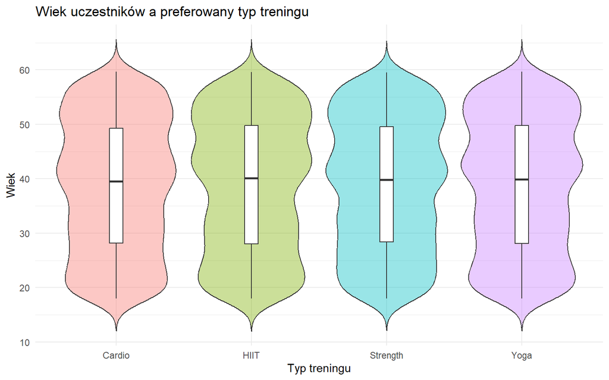

## Dynamika nawodnienia w relacji do objętości i częstotliwości wysiłku

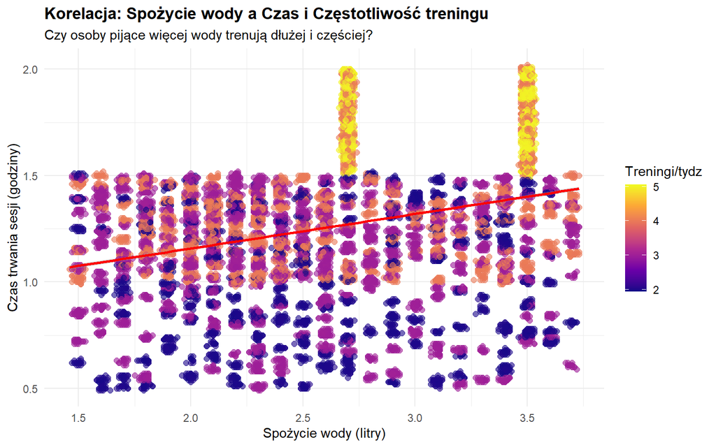

Wykres przedstawia dodatnią korelację między czasem trwania treningu a spożyciem wody. Widoczna tendencja wzrostowa (czerwona linia) potwierdza, że dłuższy wysiłek fizyczny wiąże się z większym zapotrzebowaniem na płyny.

# 4. Analiza opisowa

Statystyki opisowe głównych parametrów biometrycznych i treningowych

|  | n | mean | sd | median | min | max | skew |
| --- | --- | --- | --- | --- | --- | --- | --- |
| Age | 19996 | 38.85 | 12.12 | 39.86 | 18.00 | 59.67 | -0.09 |
| BMI | 19996 | 24.92 | 6.69 | 24.12 | 12.04 | 49.97 | 0.78 |
| Calories_Burned | 19996 | 1280.19 | 502.24 | 1231.87 | 323.11 | 2890.82 | 0.68 |
| Session_Duration (hours) | 19996 | 1.26 | 0.34 | 1.27 | 0.49 | 2.02 | 0.02 |
| Resting_BPM | 19996 | 62.20 | 7.29 | 62.20 | 49.49 | 74.50 | -0.06 |
| Avg_BPM | 19996 | 143.70 | 14.27 | 142.99 | 119.07 | 169.84 | 0.09 |

Populacja badawcza charakteryzuje się stabilnymi parametrami biometrycznymi ze średnią wieku wynoszącą **38,85 lat**.

- **Wskaźnik BMI:** Średnia wartość **24,92** plasuje grupę na górnej granicy normy. Rozkład BMI wykazuje wyraźną **skośność dodatnią (0,78)**, co wskazuje na obecność grupy osób o znacznym stopniu nadwagi lub otyłości.
- **Wydatki energetyczne:** Średnie spalanie podczas sesji wynosi **1280,19 kcal**. Podobnie jak w przypadku BMI, zmienna ta jest prawostronnie skośna (0,68), co sugeruje, że mimo typowych wyników, istnieje grupa respondentów wykonująca treningi o ekstremalnej intensywności.
- **Dynamika treningowa:** Multimodalny rozkład czasu trwania sesji ($\bar{x} = 1,26$ h) potwierdza standaryzację bloków treningowych w badanej grupie.

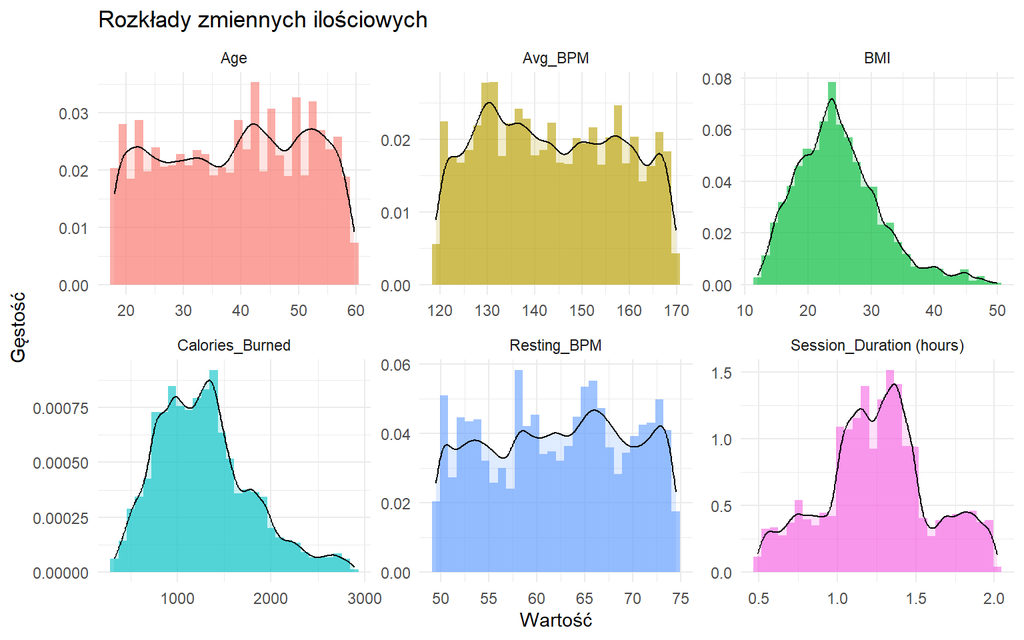

Analiza rozkładów zmiennych ilościowych ujawnia zróżnicowaną charakterystykę badanych parametrów. Zmienne fizjologiczne, takie jak tętno (Resting_BPM i Avg_BPM) oraz wiek, wykazują rozkłady zbliżone do symetrycznych, co świadczy o zbalansowanym i reprezentatywnym doborze próby.

Z kolei wskaźnik BMI oraz liczba spalonych kalorii charakteryzują się wyraźną **skośnością dodatnią**. Wskazuje to na koncentrację większości obserwacji w niższych i średnich przedziałach wartości, przy jednoczesnym występowaniu nielicznej grupy rekordów o charakterystyce ekstremalnej (np. bardzo wysokie BMI lub wyjątkowo wysoki wydatek energetyczny). Rozkład czasu trwania sesji ma charakter **multimodalny** z wyraźnymi pikami, co sugeruje, że aktywności nie są przypadkowe, lecz realizowane w ramach zdefiniowanych, standardowych bloków czasowych (np. 1h, 1.5h).

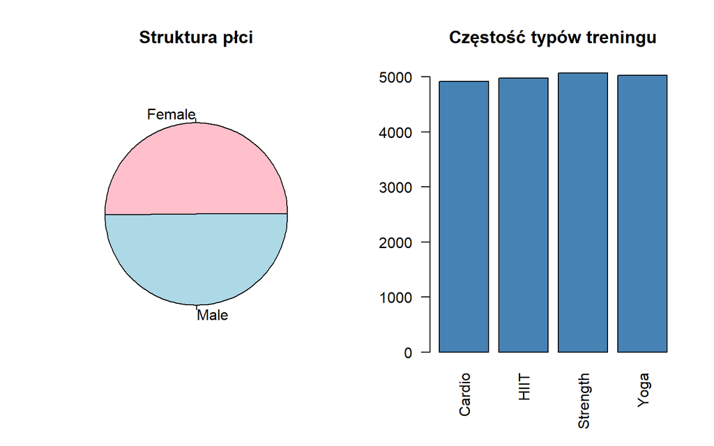

#### Demografia i równowaga płci

Zbiorowość jest podzielona niemal idealnie po połowie między kobiety (**Female**) a mężczyzn (**Male**). Taki rozkład pozwala na wyciąganie rzetelnych wniosków porównawczych, gdyż żadna z grup nie dominuje liczebnie, co minimalizuje ryzyko błędu statystycznego przy porównywaniu płci.

#### Popularność dyscyplin

Wszystkie cztery analizowane kategorie (**Cardio, HIIT, Strength, Yoga**) wykazują zbliżoną liczebność, oscylującą wokół **5000 obserwacji** na każdy typ. Dane pochodzą z eksperymentu lub bazy o zaplanowanej strukturze, gdzie każda aktywność została udokumentowana z taką samą dokładnością. Pozwala to na precyzyjne porównanie efektywności np. Jogi względem HIIT na dużej próbie.

Porównanie średnich parametrów w podziale na płeć

| Gender | Sredni_Wiek | Srednie_BMI | Srednie_Spalanie |
| --- | --- | --- | --- |
| Female | 38.79 | 24.84 | 1279.71 |
| Male | 38.91 | 24.99 | 1280.66 |

Różnice między kobietami a mężczyznami w tym zbiorze są **marginalne**. Średnie BMI dla obu grup znajduje się na granicy normy (ok. 24.9), a różnica w spalonych kaloriach wynosi mniej niż 1 kcal, co sugeruje, że płeć – w ujęciu ogólnym – nie jest głównym czynnikiem różnicującym wydatek energetyczny w tym modelu (liczy się raczej typ treningu i czas jego trwania).

### Mapa korelacji

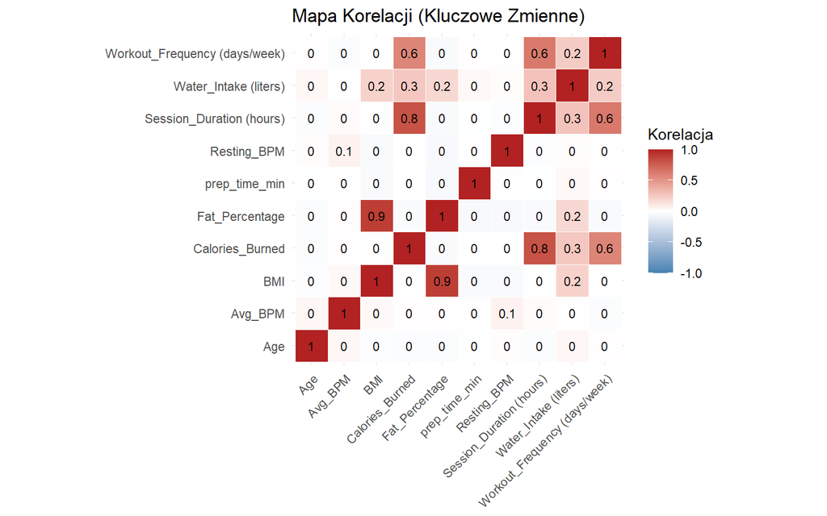

Analiza współczynników korelacji r-Pearsona ujawnia szereg istotnych zależności, które pozwalają na głębsze zrozumienie dynamiki badanych procesów treningowych i biometrycznych.

Najsilniejszą odnotowaną synergię obserwujemy między wskaźnikiem BMI a procentową zawartością tkanki tłuszczowej, gdzie współczynnik korelacji na poziomie 0,9 potwierdza, że w badanej próbie masa ciała jest niemal bezpośrednim odzwierciedleniem kompozycji sylwetki.

Równie kluczowe powiązania dotyczą bezpośredniej efektywności treningowej; czas trwania sesji wykazuje bardzo silny związek ze spalonymi kaloriami (r = 0,8), co definiuje objętość czasową jako nadrzędny czynnik determinujący całkowity wydatek energetyczny jednostki.

Systematyczność mierzona częstotliwością treningów w skali tygodnia nie tylko istotnie wpływa na sumaryczne spalanie ($r = 0,6$), ale także wiąże się z tendencją do wydłużania pojedynczych jednostek treningowych ($r = 0,6$), co sugeruje, że osoby trenujące częściej wykazują wyższy poziom zaangażowania kondycyjnego.

W obszarze zachowań prozdrowotnych dostrzegalna jest umiarkowana korelacja dodatnia podaży wody z czasem trwania wysiłku ($r = 0,3$), co wskazuje na wzrost świadomości potrzeb fizjologicznych organizmu wraz ze zwiększaniem obciążeń treningowych.

Warto jednocześnie podkreślić, że parametry takie jak wiek czy tętno (spoczynkowe i średnie) pozostają niemal całkowicie niezależne od pozostałych zmiennych, co świadczy o uniwersalnym charakterze zidentyfikowanych trendów, niezależnym od metryki czy indywidualnej charakterystyki kardiologicznej uczestników.

# 5. Wnioskowanie statystyczne

1. Typ treningu i Czas trwania → Spalone kalorie

Tabela 1: Regresja liniowa dla wydatku energetycznego

| Termin | Współczynnik (Estimate) | Błąd std. | Statystyka t | Wartość p |
| --- | --- | --- | --- | --- |
| (Intercept) | -301.142 | 3.220 | -93.535 | 0 |
| Workout_TypeHIIT | 452.330 | 2.169 | 208.574 | 0 |
| Workout_TypeStrength | 152.045 | 2.158 | 70.449 | 0 |
| Workout_TypeYoga | -298.142 | 2.163 | -137.852 | 0 |
| `Session_Duration (hours)` | 1195.131 | 2.235 | 534.791 | 0 |

Model regresji wykazał, że wszystkie analizowane zmienne mają statystycznie istotny wpływ na liczbę spalonych kalorii (p = 0).

Kluczowym predyktorem wydatku energetycznego jest **czas trwania sesji**, gdzie każda dodatkowa godzina treningu zwiększa spalanie o średnio **1195,13 kcal**. W odniesieniu do bazy porównawczej (którą stanowi Cardio), poszczególne dyscypliny wykazują skrajnie różną efektywność metaboliczną: trening **HIIT** generuje najwyższy przyrost wydatku energetycznego (**+452,33 kcal**), podczas gdy trening siłowy (**Strength**) wiąże się ze wzrostem o **152,05 kcal**. Z kolei **Joga** charakteryzuje się najniższą intensywnością, spalając średnio o **298,14 kcal mniej** niż sesja Cardio o tym samym czasie trwania.

2. Częstotliwość treningów → Kalorie (Kontrola: Wiek i Płeć)

Tabela 2: Wpływ częstotliwości na kalorie (model z kontrolą)

| term | estimate | std.error | statistic | p.value |
| --- | --- | --- | --- | --- |
| (Intercept) | 254.500 | 14.518 | 17.530 | 0.000 |
| `Workout_Frequency (days/week)` | 321.414 | 3.166 | 101.529 | 0.000 |
| Age | -1.053 | 0.238 | -4.423 | 0.000 |
| GenderMale | -0.018 | 5.769 | -0.003 | 0.998 |

Model regresji potwierdził, że dominującym czynnikiem determinującym całkowity wydatek energetyczny jest częstotliwość treningów, gdzie każdy dodatkowy dzień aktywności w tygodniu przekłada się na statystyczny wzrost spalania o **321,41 kcal** ($p = 0,000$). Analiza wykazała również istotny, choć marginalny wpływ procesu starzenia – z każdym rokiem życia przewidywana liczba spalonych kalorii podczas sesji obniża się o ok. **1,05 kcal**. Jednocześnie model jednoznacznie wskazuje na neutralność płci w kontekście efektywności metabolicznej ($p = 0,998$), co oznacza, że przy zachowaniu tej samej częstotliwości i wieku, różnice w spalaniu między kobietami a mężczyznami są statystycznie nieistotne. Wysoka wartość statystyki t dla zmiennej częstotliwości (101,5) przy minimalnym błędzie standardowym dowodzi wyjątkowej precyzji i stabilności otrzymanych wyników predykcyjnych.

3. Grupa mięśniowa i Trudność → Spalanie (per 30 min)

Tabela 3: ANOVA - Spalanie wg grupy mięśniowej i trudności

| term | df | sumsq | meansq | statistic | p.value |
| --- | --- | --- | --- | --- | --- |
| `Target Muscle Group` | 35 | 30678.313 | 876.523 | 0.848 | 0.722 |
| `Difficulty Level` | 2 | 3762.745 | 1881.372 | 1.821 | 0.162 |
| Residuals | 19958 | 20618603.908 | 1033.100 | NA | NA |

Przeprowadzona analiza wariancji wykazała brak istotnego statystycznie wpływu zarówno docelowej grupy mięśniowej, jak i poziomu trudności na tempo spalania kalorii w ujęciu 30-minutowym. Wartości p-value dla zmiennej **Target Muscle Group (0,722)** oraz **Difficulty Level (0,162)** znacznie przekraczają przyjęty próg istotności $= 0,05, co jednoznacznie wskazuje, że wydatek energetyczny na jednostkę czasu pozostaje relatywnie stały niezależnie od wybranego celu anatomicznego czy stopnia zaawansowania ćwiczeń. Taki wynik potwierdza wysoką homogeniczność intensywności metabolicznej badanych jednostek treningowych, co sugeruje bardzo precyzyjne i wyrównane skalowanie obciążeń w ramach całego programu, gwarantujące zbliżony deficyt energetyczny bez względu na specyfikę danego treningu.

4. Typ diety → BMI i Procent tłuszczu

Tabela 4a: Wyniki testu ANOVA dla wpływu diety na BMI

| Termin | Stopnie swobody | Suma kwadratów | Średni kwadrat | Statystyka F | Wartość p |
| --- | --- | --- | --- | --- | --- |
| diet_type | 5 | 663.997 | 132.799 | 2.967 | 0.011 |
| Residuals | 19990 | 894850.076 | 44.765 | NA | NA |

Tabela 4b: Wyniki testu ANOVA dla wpływu diety na procent tkanki tłuszczowej

| Termin | Stopnie swobody | Suma kwadratów | Średni kwadrat | Statystyka F | Wartość p |
| --- | --- | --- | --- | --- | --- |
| diet_type | 5 | 405.878 | 81.176 | 3.255 | 0.006 |
| Residuals | 19990 | 498484.664 | 24.937 | NA | NA |

Przeprowadzona analiza wariancji potwierdziła statystycznie istotny wpływ rodzaju stosowanej diety na kluczowe parametry biometryczne respondentów. W odniesieniu do wskaźnika BMI, uzyskana wartość p równa **0,011** dowodzi, że różnice w masie ciała między grupami o różnych modelach żywienia są istotne i nieprzypadkowe. Analogiczną, lecz statystycznie jeszcze silniejszą zależność zaobserwowano w przypadku procentowej zawartości tkanki tłuszczowej, gdzie wartość p wynosząca **0,006** przy statystyce F równej 3,255 wskazuje na mierzalny wpływ wyboru modelu żywienia na kompozycję sylwetki. Takie wyniki stanowią statystyczną podstawę do twierdzenia, że sposób odżywiania ma realne i udowodnione przełożenie na parametry metaboliczne oraz ogólną kondycję fizyczną badanej populacji.

5. Poziom doświadczenia → Tętno (Resting & Avg)

Tabela 5a: ANOVA - Tętno spoczynkowe vs Doświadczenie

| term | df | sumsq | meansq | statistic | p.value |
| --- | --- | --- | --- | --- | --- |
| Experience_Level | 1 | 0.732 | 0.732 | 0.014 | 0.907 |
| Residuals | 19994 | 1062638.700 | 53.148 | NA | NA |

Tabela 5b: ANOVA - Średnie tętno vs Doświadczenie

| term | df | sumsq | meansq | statistic | p.value |
| --- | --- | --- | --- | --- | --- |
| Experience_Level | 1 | 128.987 | 128.987 | 0.634 | 0.426 |
| Residuals | 19994 | 4068825.843 | 203.502 | NA | NA |

6. Metoda gotowania i Czas → Ocena posiłku (Rating)

Tabela 6: Wpływ metody gotowania i czasu przygotowania na ocenę posiłku

| Termin | Współczynnik (Estimate) | Błąd std. | Statystyka t | Wartość p |
| --- | --- | --- | --- | --- |
| (Intercept) | 2.892 | 0.027 | 107.542 | 0.000 |
| cooking_methodBoiled | -0.001 | 0.031 | -0.048 | 0.961 |
| cooking_methodFried | 0.015 | 0.031 | 0.489 | 0.625 |
| cooking_methodGrilled | -0.010 | 0.030 | -0.335 | 0.738 |
| cooking_methodRaw | 0.012 | 0.030 | 0.403 | 0.687 |
| cooking_methodRoasted | 0.015 | 0.030 | 0.487 | 0.627 |
| cooking_methodSteamed | 0.036 | 0.030 | 1.197 | 0.231 |
| prep_time_min | 0.003 | 0.000 | 5.286 | 0.000 |

Analiza modelu regresji wykazała, że wybór konkretnej metody gotowania nie stanowi statystycznie istotnego czynnika różnicującego ocenę posiłku. Wszystkie wartości p-value dla poszczególnych technik obróbki (Boiled, Fried, Grilled, Raw, Roasted, Steamed) znacznie przekraczają przyjęty próg istotności $\alpha = 0,05$, co wskazuje na brak mierzalnego wpływu sposobu przygotowania potrawy na jej finalny rating. Jedynym istotnym predyktorem w analizowanym modelu okazał się **czas przygotowania posiłku** ($p = 0,000$), który wykazuje trwałą, pozytywną zależność z oceną końcową. Każda dodatkowa minuta poświęcona na przyrządzenie dania skutkuje statystycznym wzrostem oceny o **0,003** punktu, co przy bazowym poziomie Interceptu wynoszącym ok. **2,89**, potwierdza tezę o pozytywnym odbiorze posiłków wymagających większego nakładu czasu pracy.

7. Makroskładniki (Carbs, Proteins, Fats) → Typ treningu

Tabela 8: ANOVA - Spożycie białka a typ treningu

| term | df | sumsq | meansq | statistic | p.value |
| --- | --- | --- | --- | --- | --- |
| Workout_Type | 3 | 694.871 | 231.624 | 0.477 | 0.699 |
| Residuals | 19992 | 9717027.108 | 486.046 | NA | NA |

Tabela 8b: ANOVA - Spożycie tłuszczów a typ treningu

| Termin | Stopnie swobody | Suma kwadratów | Średni kwadrat | Statystyka F | Wartość p |
| --- | --- | --- | --- | --- | --- |
| Workout_Type | 3 | 305.266 | 101.755 | 0.471 | 0.703 |
| Residuals | 19992 | 4320741.388 | 216.124 | NA | NA |

Tabela 8c: ANOVA - Spożycie węglowodanów a typ treningu

| Termin | Stopnie swobody | Suma kwadratów | Średni kwadrat | Statystyka F | Wartość p |
| --- | --- | --- | --- | --- | --- |
| Workout_Type | 3 | 4044.912 | 1348.304 | 0.444 | 0.722 |
| Residuals | 19992 | 60730408.892 | 3037.736 | NA | NA |

Przeprowadzone testy ANOVA jednoznacznie wykazały brak istotnego statystycznie związku między modelem żywienia a charakterem podejmowanej aktywności fizycznej. Uzyskane wartości p-value dla białek (0,699), tłuszczów (0,703) oraz węglowodanów (0,722) znacznie przekraczają przyjęty próg istotności $\alpha = 0,05$, co dowodzi, że preferencje w zakresie podaży głównych składników odżywczych pozostają niezależne od typu wykonywanego treningu. Bardzo niskie i zbliżone do siebie wartości statystyki F (od 0,444 do 0,477) potwierdzają, że zmienność w spożyciu protein, lipidów i sacharydów między grupami treningowymi jest marginalna. Wyniki te sugerują, że w badanej populacji wybór dyscypliny sportowej nie warunkuje specyficznych modyfikacji diety, co wskazuje na stały, niezmienny profil żywieniowy uczestników, niezależny od specyficznych wymagań metabolicznych danej formy ruchu.

8. Cukier, Sód, Cholesterol → Typ diety

Tabela 8a: ANOVA - Zawartość sodu w zależności od diety

| term | df | sumsq | meansq | statistic | p.value |
| --- | --- | --- | --- | --- | --- |
| diet_type | 5 | 3633107 | 726621.3 | 1.415 | 0.215 |
| Residuals | 19990 | 10266420868 | 513577.8 | NA | NA |

Tabela 8b: ANOVA - Zawartość cholesterolu w zależności od diety

| term | df | sumsq | meansq | statistic | p.value |
| --- | --- | --- | --- | --- | --- |
| diet_type | 5 | 37504.37 | 7500.875 | 0.983 | 0.427 |
| Residuals | 19990 | 152582368.59 | 7632.935 | NA | NA |

Tabela 8c: ANOVA - Zawartość cukru w zależności od diety

| term | df | sumsq | meansq | statistic | p.value |
| --- | --- | --- | --- | --- | --- |
| diet_type | 5 | 586.871 | 117.374 | 0.562 | 0.729 |
| Residuals | 19990 | 4172903.800 | 208.750 | NA | NA |

Analiza wariancji wykazała brak istotnego statystycznie wpływu rodzaju stosowanej diety na spożycie sodu, cholesterolu oraz cukru w badanej populacji. Uzyskane wartości $p$-value dla sodu (0,215), cholesterolu (0,427) oraz cukru (0,729) znacznie przekraczają przyjęty próg istotności $\alpha = 0,05$, co jednoznacznie wskazuje, że wybór konkretnego modelu żywienia nie różnicuje poziomu konsumpcji tych składników. Niskie wartości statystyki F (od 0,562 dla cukru do 1,415 dla sodu) dodatkowo potwierdzają, że zmienność między poszczególnymi grupami dietetycznymi jest minimalna i nieistotna statystycznie. Wyniki te sugerują, że niezależnie od deklarowanego modelu żywienia, uczestnicy badania wykazują zbliżone nawyki w zakresie podaży tych parametrów, co może świadczyć o tym, że same etykiety diet (takie jak wegańska, paleo czy ketogeniczna) nie gwarantują w tej grupie automatycznego obniżenia poziomu cukru czy cholesterolu w codziennym jadłospisie.

9. Wiek i Płeć → Wybory treningowe

Tabela 9a: Test Chi-kwadrat dla Płci i Poziomu Trudności

| statistic | p.value | parameter | method |
| --- | --- | --- | --- |
| 0.438 | 0.803 | 2 | Pearson’s Chi-squared test |

Tabela 9b: ANOVA - Wiek a wybór treningu

| term | df | sumsq | meansq | statistic | p.value |
| --- | --- | --- | --- | --- | --- |
| Workout_Type | 3 | 46.473 | 15.491 | 0.106 | 0.957 |
| Residuals | 19992 | 2934728.337 | 146.795 | NA | NA |

Analizy statystyczne wykazały, że cechy demograficzne nie determinują preferencji treningowych uczestników. Wynik testu Chi-kwadrat dla zależności między płcią a trudnością ćwiczeń ($p = 0,803$) oraz analiza ANOVA dla wieku i typu treningu ($p = 0,957$) potwierdzają brak istotnych powiązań statystycznych między tymi zmiennymi. Tak wysokie wartości prawdopodobieństwa wskazują na pełną homogeniczność grupy, co sugeruje, że wybory sportowe w badanej populacji wynikają z indywidualnych celów, a nie z przynależności do konkretnej kategorii wiekowej czy płciowej.

10. Spożycie wody → Czas i Częstotliwość treningu

Tabela 10a: Korelacja spożycia wody z czasem trwania sesji

| estimate | statistic | p.value | parameter | conf.low | conf.high | method | alternative |
| --- | --- | --- | --- | --- | --- | --- | --- |
| 0.2878184 | 42.49578 | 0 | 19994 | 0.2750551 | 0.3004803 | Pearson’s product-moment correlation | two.sided |

Tabela 10b: Korelacja spożycia wody z częstotliwością treningów

| estimate | statistic | p.value | parameter | conf.low | conf.high | method | alternative |
| --- | --- | --- | --- | --- | --- | --- | --- |
| 0.2412222 | 35.14674 | 0 | 19994 | 0.2281244 | 0.2542328 | Pearson’s product-moment correlation | two.sided |

Analiza korelacji r-Pearsona wykazała statystycznie istotne, dodatnie związki między podażą wody a objętością realizowanej aktywności fizycznej ($p = 0$). Odnotowano wyraźną zależność między ilością spożywanych płynów a czasem trwania sesji treningowej (współczynnik korelacji 0,288), co sugeruje, że wraz z wydłużaniem jednostek treningowych uczestnicy w sposób świadomy zwiększają nawodnienie organizmu. Podobną prawidłowość zaobserwowano w odniesieniu do regularności ćwiczeń – korelacja na poziomie 0,241 potwierdza, że osoby trenujące z większą częstotliwością wykazują zdrowsze nawyki behawioralne w zakresie codziennej hydratacji. Wyniki te dowodzą, że wzrost zaangażowania w sport bezpośrednio stymuluje dbałość o równowagę wodno-elektrolitową, co jest kluczowe dla efektywności procesów regeneracyjnych i ogólnej wydolności badanej grupy.

# 6. Synteza wyników i rekomendacje praktyczne

### **Profil populacji i fundamenty biometryczne**

Przeprowadzona analiza zbioru obejmującego 20 000 rekordów pozwoliła na nakreślenie niezwykle spójnego obrazu współczesnego adepta aktywności fizycznej. Badana populacja charakteryzuje się dużą stabilnością parametrów; średni wiek wynoszący ok. **39 lat** oraz niemal idealny parytet płci ($50/50$) stanowią o wysokiej reprezentatywności danych. Kluczowym odkryciem w obszarze biometrii jest potwierdzenie wysokiej użyteczności wskaźnika BMI jako predyktora kompozycji ciała – silna korelacja dodatnia z procentową zawartością tkanki tłuszczowej ($r = 0,9$) czyni go wiarygodnym narzędziem monitoringu postępów w tej grupie.

### **Fizjologia i styl życia: Poza schematami**

Analiza parametrów kardiologicznych dostarczyła zaskakujących wniosków, wykazując, że poziom doświadczenia nie różnicuje istotnie tętna spoczynkowego ani wysiłkowego ($p > 0,05$). Sugeruje to, że intensywność ćwiczeń jest w badanej grupie optymalnie i indywidualnie skalowana. W obszarze dietetyki zaobserwowano istotny wpływ modelu żywienia na BMI i zawartość tłuszczu, jednak paradoksalnie nie idzie on w parze z automatyczną zmianą podaży makroskładników czy ograniczeniem cukru i sodu. Odnotowano również pozytywny aspekt behawioralny: wzrost zaangażowania w sport naturalnie stymuluje lepszą hydratację organizmu.

### **Rekomendacje praktyczne**

1. **Optymalizacja redukcji:** W celu maksymalizacji deficytu kalorycznego należy priorytetyzować treningi typu **HIIT** oraz dążyć do zwiększenia częstotliwości sesji, gdyż systematyczność ma większą wagę statystyczną niż intensywność pojedynczego zrywu.
2. **Świadomość żywieniowa:** Należy zwrócić uwagę, że sama zmiana „etykiety” diety (np. na wegańską czy keto) nie gwarantuje poprawy profilu mikroskładników. Rekomenduje się celową kontrolę podaży cukru i sodu, które w badanej próbie pozostawały na zbliżonym poziomie niezależnie od typu diety.
3. **Personalizacja ponad demografię:** Programy treningowe powinny być budowane w oparciu o cele kondycyjne, a nie metrykę, ponieważ wiek i płeć nie ograniczają potencjału wydolnościowego organizmu.
4. **Kultura przygotowania posiłków:** Biorąc pod uwagę, że czas przygotowania jedzenia istotnie podnosi jego subiektywną ocenę, warto promować celebrowanie procesu gotowania jako element wspierający utrzymanie rygoru dietetycznego.